# Project: Investigate a Dataset (FBI Gun Data!)

### For employment vuslization , it states clearly that there is no relation for this data and gun usage

```python
df_firms = pd.DataFrame(index=df_2.index)
df_firms = df_2[['All firms, 2012','Men-owned firms, 2012' ,'Women-owned firms, 2012','Minority-owned firms, 2012',
'Nonminority-owned firms, 2012','Veteran-owned firms, 2012','Nonveteran-owned firms, 2012']]
#Convert from string to integers
ConvertSeries(df_firms,percent=False)

#Then we can extract the 2012 Gun data
Gun_2012 = ExtractData("2012")
assert len(Gun_2012) == 50 #Then we have 50 rows in Gun_2012 corresponding to 50 states with average gun usage in 2012
```

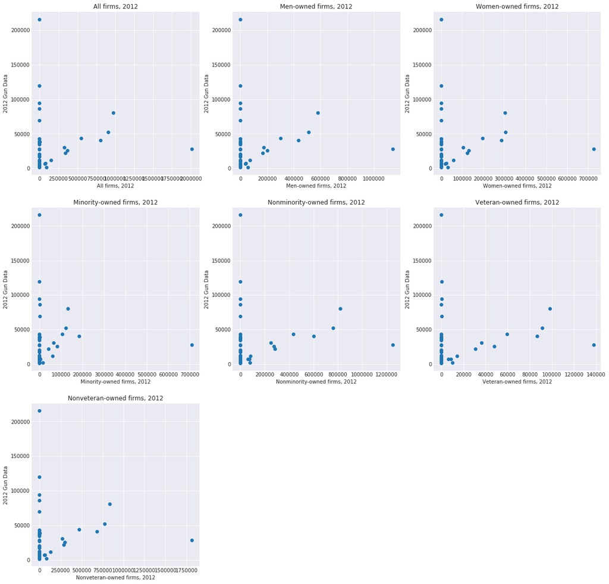

```python
PlotScatter(3,3,df_firms,Gun_2012)
```

## Obviously from the visualization , there is no clear relation for those datasets between owned firms data and gun usage data

```python
#so finally we will check for the population per square miles data
Pop_Mile = pd.DataFrame(index=df_2.index)
Pop_Mile['Population per square mile, 2010'] = df_2['Population per square mile, 2010']
ConvertSeries(Pop_Mile,percent=False)
#Then we will extract 2010 Gun data
Gun_2010 = ExtractData("2010")
assert len(Gun_2010) == 50 #Then we have 50 rows in Gun_2010 corresponding to 50 states with average gun usage in 2010
```

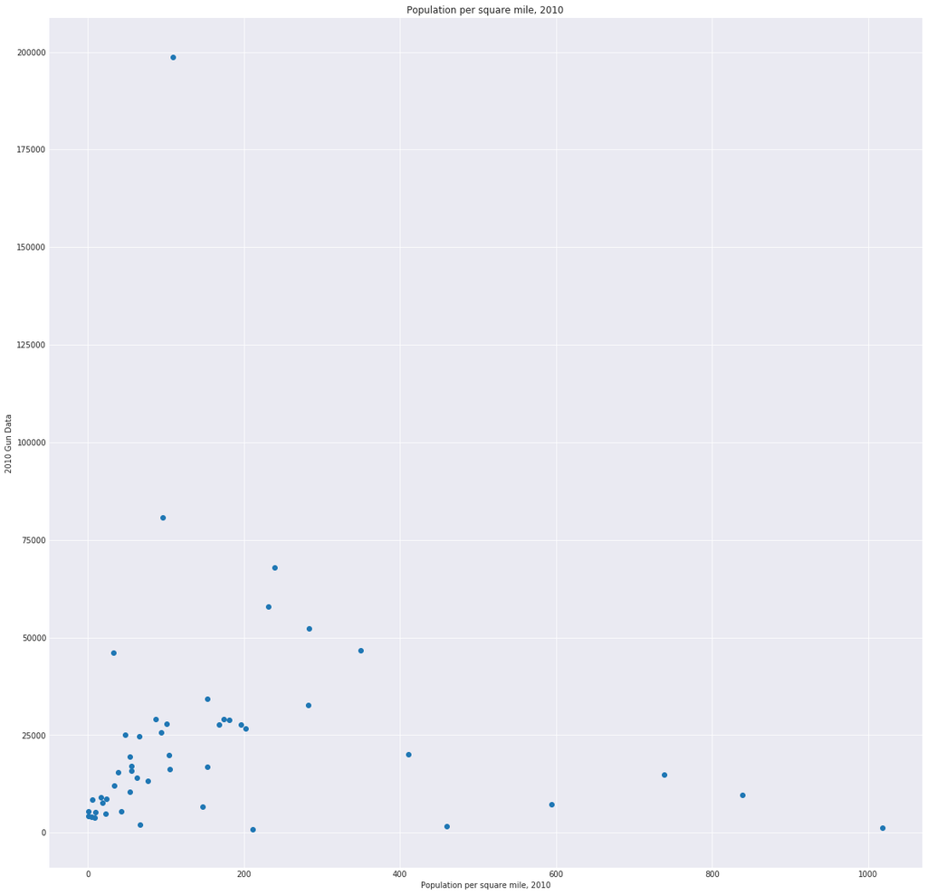

```python
PlotScatter(1,1,Pop_Mile,Gun_2010)
```

# Question 3(What Census Data related to high gun usage ?)

## Answer:

> First, the census data analyzed to get those conclusions were (Age Data,Race Data,Firm Data,Employment Data,Population Data)

> For all data, the propportionality was so weak, my hypothesis was that this happened due to low number of Datapoints used in the plots (Only 50)

## Research Question 4 (Which state had the biggest increase in total gun usage?)

```python
#To Begin answering question 4 , we need to make the State columns ready
#First observation we had is that during the drop of duplicates and na rows, we had some states without full data (less than 227 rows)
#Those states were Virgin islands and Colorado, so to plot all of the states on the same period we need to get rid of the missing
#Periods from all the states, then plot all together
months = df_1['month'].unique()
Incomplete_Months = []
Z=[]
df_Clean = df_1
for item in months:
    if(len(df_1[df_1['month']==item]) != 55):
        Incomplete_Months.append(item) #Because if a month doesn't have 55 states then it is not complete
        idx = np.where(months == item) #Get the index where this month are found
        months = np.delete(months,idx[0][0]) #Delete This month from months list to use it as x-axis in plot
        Z = df_1.index[df_1['month']==item] #Get list of indices of the incomplete month
        df_Clean = df_Clean.drop(Z) #Drop the rows which is in this month
print(len(Incomplete_Months))
print(len(months))
```

```
22
205
```

```python
#This function is used to convert the readings to be relative to the first reading of the state (Since we are aiming to visualize
#An increase , not the absolute value of gun usage)
def ConvertToRelative(DataFrame):
    df_States = pd.DataFrame()
    for item in States_Census:
        assert len(DataFrame[DataFrame['state']==item]) == 205

        X = list(DataFrame[DataFrame['state']==item]['totals']) #
        X = X[::-1]
        if(X[0]!=0):
            df_States[item] = X/X[0]
    return df_States

df_States = ConvertToRelative(df_Clean)
```

```
Text(0,0.5,'Gun Usage')
```

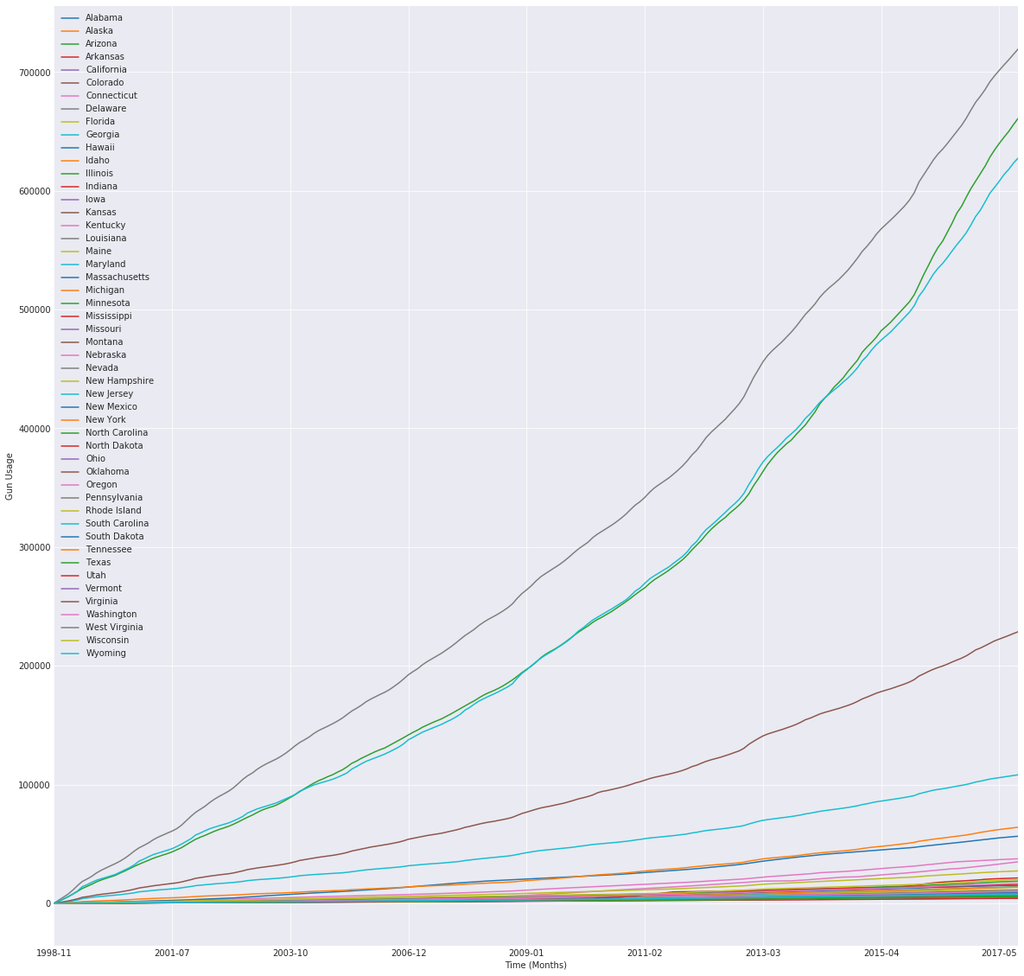

```python
#We will use the cumsum function to find the cumulative  sum of each column , cumulative sum of the relative gun usage will detect
#The state with the largest increase in rate of gun usage , as cumulative will give us the sum of relative usage around the last 100 months
df = df_States.cumsum()
plt.figure()
df.plot(x = months[::-1],figsize=(20,20))
plt.legend(loc='best')
plt.xlabel('Time (Months)')
plt.ylabel('Gun Usage')
```

```
Text(0,0.5,'Gun Usage')
```

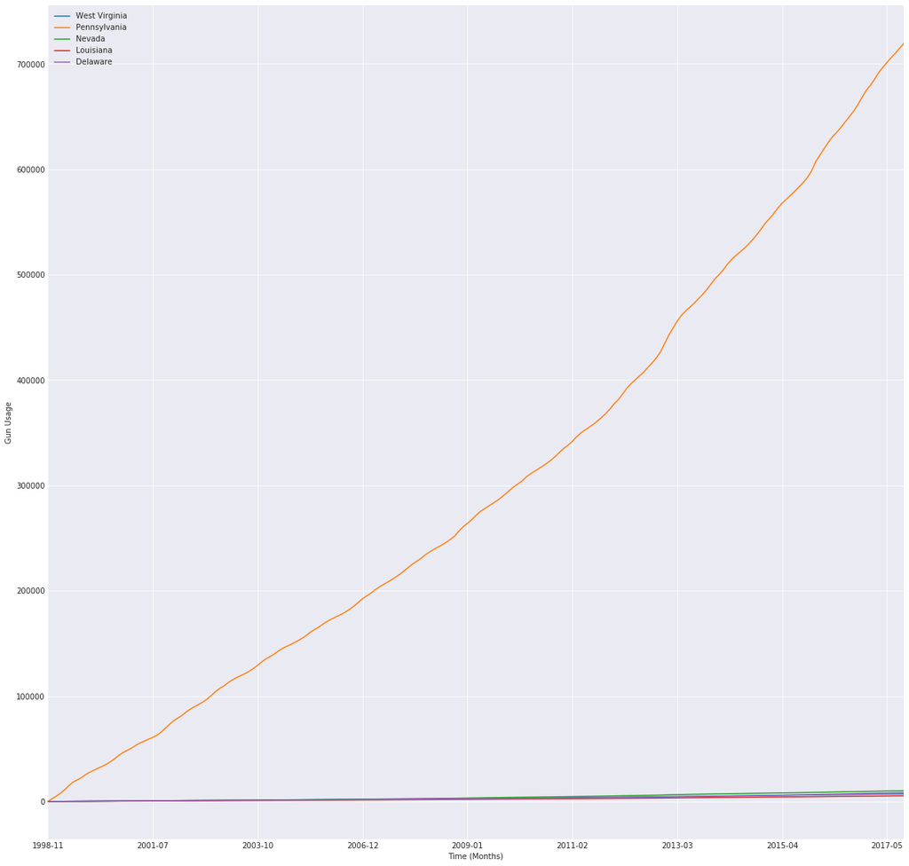

```python
#Since the last visualization had 5 states per color , and the maximum is of the grey color ,
#then we plot the grey color states
df[['West Virginia','Pennsylvania','Nevada','Louisiana','Delaware']].plot(x = months[::-1],figsize=(20,20))
plt.legend()
plt.xlabel('Time (Months)')
plt.ylabel('Gun Usage')
```

# Answer to Question 4 (Which State had the biggest increase in gun usage)

## Answer:

> Using the gun data on the periods we have (from 1998 to 2017) we found that the state Pennsylvania had the biggest growth in gun usage.

## Conclusions

> 1- The Gun Usage has increased for the past 20 years

> 2- The Gun Usage trend is Hand guns for the past 4 years

> 4- The highest increase in gun usage from 1998 to 2017 was for the state of Pennsylvania

> 5- Since There were a limitations like low number of data points in Census Data that didn't help seek the right relations with scatter plots, the answer of question 3 maybe not very accurate

```python
from subprocess import call
call(['python', '-m', 'nbconvert', 'Investigate_a_Dataset.ipynb'])
```

```
0
```